# Прогнозирование временных рядов с помощью модели ARIMA

Морозова Ю.А., Баркова З.А.

2017-11-27

# Введение

```r
library(tidyverse)
library(lubridate)
library(zoo)
library(forecast)
library(tseries)
library(fpp2)
```

Модель ARIMA сочетает в себе модель авторегрессии порядка *p* (*AR(p)*), являющуюся линейной комбинацией *p* предыдущих значений ряда; и модель скользящего среднего порядка *q* (*MA(q)*), являющуюся линейной комбинацией *q* последних значений шумовой компоненты (ошибки прогноза). В модели *ARIMA(p,d,q)* параметр *d* показывает порядок дифференцирования ряда (здесь дифференцирование - это вычитание с шагом 1, т.е. из текущего значения вычитается предыдущее). В модели *ARIMA(p,d,q)(P,D,Q)* параметры, обозначающиеся заглавными буквами обозначают то же самое, что и маленькими буквами, но для сезонности.

Здесь стоит ввести понятие стационарности временного ряда. Предположение о стационарности включает в себя [следующие условия](https://ru.coursera.org/learn/ekonometrika/lecture/EcjWV/8-1-1-statsionarnyie-i-niestatsionarnyie-riady):

- математические ожидания значений ряда равны, то есть он не имеет выраженного тренда

$$E(y_1) = E(y_2) = ... =E(y_n) = const$$

- дисперсия значений ряда постоянна

$$Var(y_1) = Var(y_2) = ...=Var(y_n)= \gamma_0$$

- ковариация (сила линейной связи) между соседними значениями ряда постоянна

$$Cov(y_1,y_2) = ... = Cov(y_{n-1},y_n) = \gamma_1$$

- последнее условие можно записать в общем виде для любого шага между значениями - сила линейной связи между значениями отстоящими друг от друга на один и тот же шаг постоянна, то есть эта связь не зависит от времени, а зависит только от “расстояния”" между двумя выбранными точками

$$Cov(y_t,y{t-k}) = \gamma_k$$

Существует теорема Вольда, которая гласит, что любой стационарный ряд (распределение значений которого не зависит от времени) может быть описан моделью *ARMA(p,q)*. Соответственно, если ряд имеет тренд либо сезонность (либо и то, и другое), он не является стационарным, а следовательно модель *ARMA(p,q)* не сможет на нем работать.

Рассмотрим несколько временных рядов: 1) данные о ежедневной аренде велосипедов; 2) данные о поголовье рыси по годам; 3) данные о пассажирообороте на американских авиалиниях по месяцам.

```r
bike <- read.csv('data/day.csv') #чтение файлов данных
passml <- read.csv('data/monthly-us-air-passenger-miles-j.csv')
```

```r
bike$dteday = as.Date(bike$dteday) #приведение даты к нужному формату
passml$date = as.yearmon(passml$Month)
```

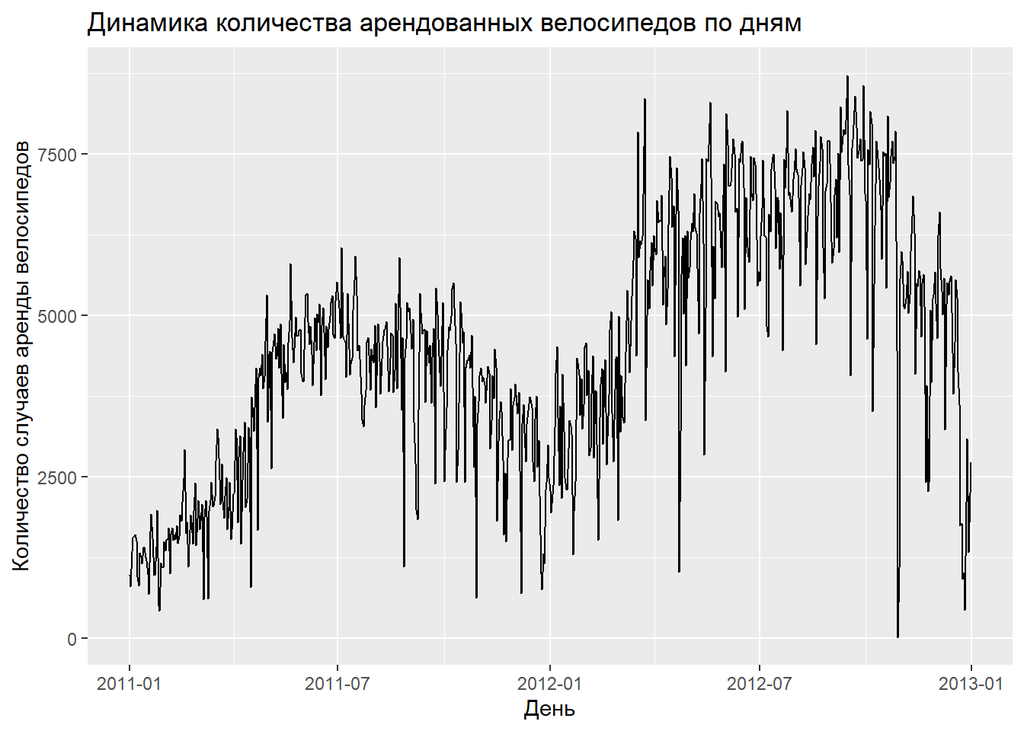

```r
ggplot(bike, aes(dteday, cnt)) + #построение графиков
  geom_line() +
  labs(title="Динамика количества арендованных велосипедов по дням") +
  ylab("Количество случаев аренды велосипедов") +
  xlab("День")
```

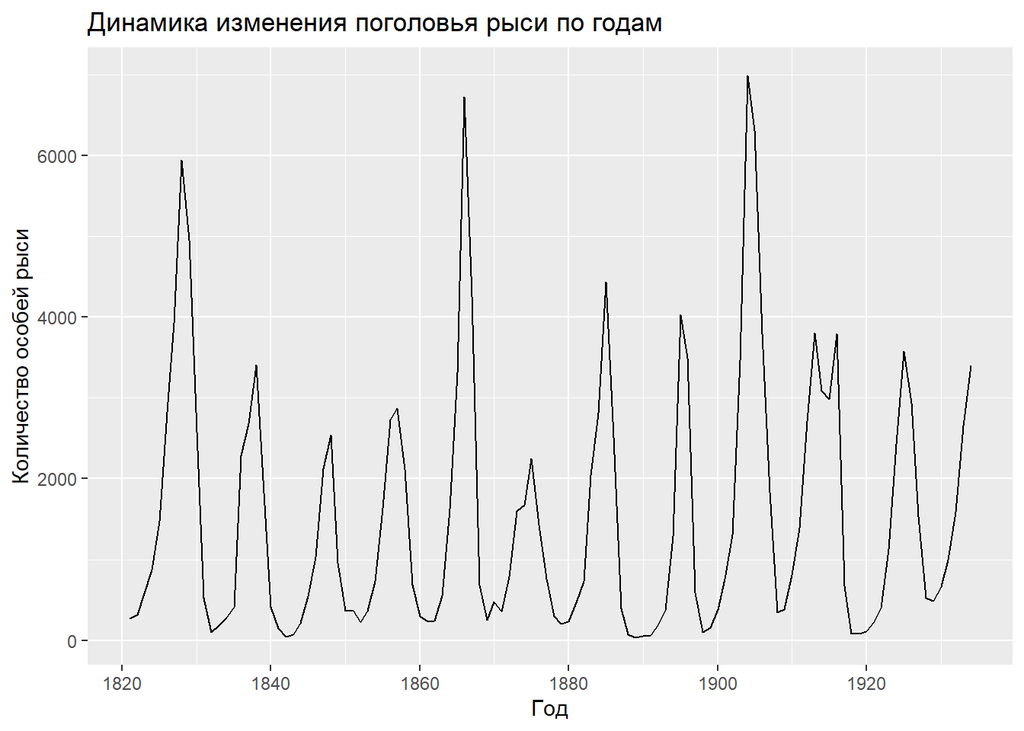

```r
autoplot(lynx) +
  labs(title ="Динамика изменения поголовья рыси по годам") +
  ylab("Количество особей рыси") +
  xlab("Год")
```

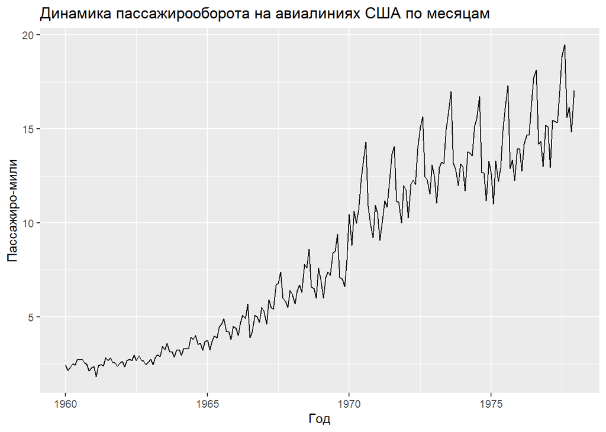

```r
ggplot(passml, aes(date, Passenger_miles)) +
  geom_line() +
  labs(title = "Динамика пассажирооборота на авиалиниях США по месяцам") +
  ylab("Пассажиро-мили") +
  xlab("Год")
```

Временной ряд для аренды велосипедов будет нестационарным из-за наличия тренда, временной ряд изменения пассажирооборота на авиалиниях также является нестационарным, так как ярко выражен как тренд, так и сезонность, а кроме того, дисперсия значений ряда увеличивается со временем. Временной ряд изменения поголовья рыси считается стационарным, хотя в нем есть цикличность, но цикличность в данном случае носит случайный характер и ее нельзя точно предсказать.

Далее будем рассматривать построение моделей на примере временного ряда о пассажирообороте на авиалиниях США. График выглядит довольно “аккуратно”, выбросов на нем не видно. Если бы были выбросы, можно было бы сгладить выбросы с помощью функции `tsclean()` из библиотеки `forecast`.

Проверим ряд на наличие пропущенных значений:

```r
sum(is.na(passml$Passenger_miles))
```

```
## [1] 0
```

# Компоненты ряда

Временной ряд может включать в себя несколько компонентов (не всегда включает все). Есть 4 основных составляющих временного ряда - тренд, сезонность, циклическая компонента и шумовая компонента. Разложим рассмариваемый ряд на составные части:

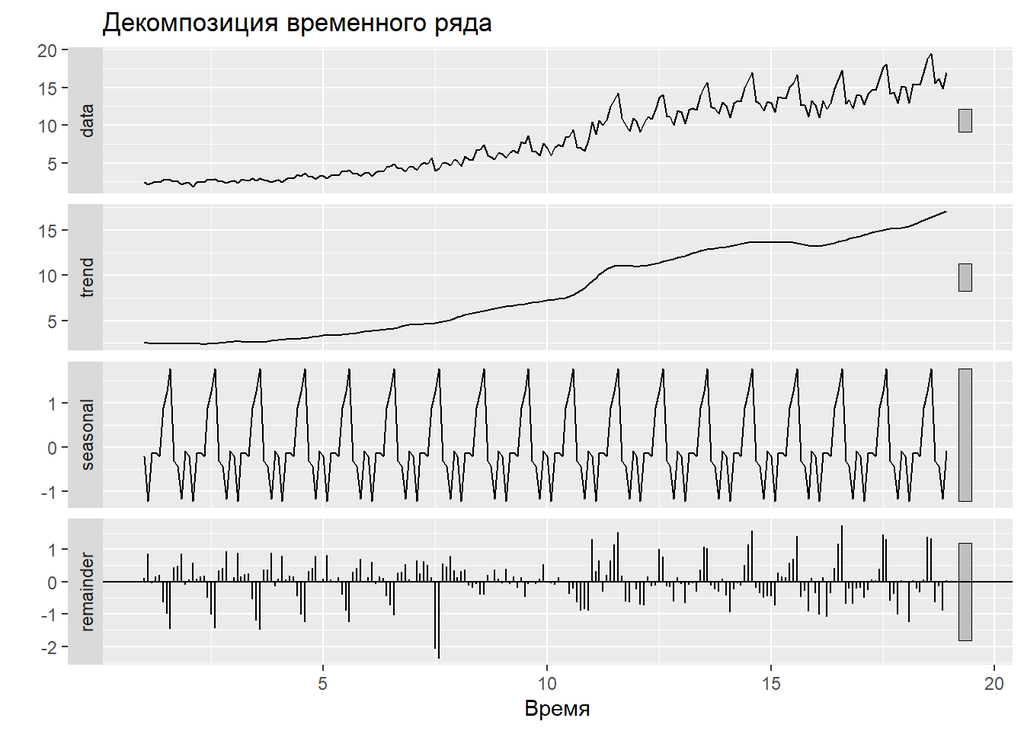

```r
pmiles <- ts(na.omit(passml$Passenger_miles), frequency=12)
decomp <- stl(pmiles, s.window="periodic")
deseasonal_cnt <- seasadj(decomp)
autoplot(decomp) +
  labs(title = "Декомпозиция временного ряда",
       x = "Время")
```

# Как сделать временной ряд стационарным

## Проверка на стационарность

Чтобы применить модель ARIMA на нашем временном ряде, необходимо привести его к стационарному виду. Как было видно и до, и после деления ряда на составляющие, наш ряд делают нестационарным три основные вещи: 1) тренд, 2) сезонность, 3) рост дисперсии сезонного размаха. К этому заключению мы пришли после визуального анализа, но нужно что-то более конкретное, чтобы убедиться, стационарен наш ряд или нет.

Для этого случая существует статистический [критерий Дики-Фуллера](https://en.wikipedia.org/wiki/Dickey-Fuller_test). В качестве нулевой гипотезы обычно рассматривается гипотеза о нестационарности ряда, в качестве альтернативы - то, что ряд стационарен. Соответственно, мы сможем отвергнуть гипотезу о нестационарности временного ряда в том случае, если p-value < 0.05 (при 95% уровне значимости).

*Критерий Дики-Фуллера:*

Временной ряд: $y^T = y_1,..., y_T$ ;

Нулевая гипотеза: $H_0:$ ряд нестационарен;

Альтернативная гипотеза: $H_1:$ ряд стационарен.

В данном примере будем использовать расширенный тест Дики-Фуллера (augmented Dikey-Fuller test), имеющийся в библиотеке `tseries`. Однако, у этого теста есть особенность в том, что сезонность ряда как-то влияет на его результат (именно в реализации на R). Поскольку у нас период составляет год, то укажем, что в периоде 12 месяцев.

```r
adf.test(pmiles, k=12, alternative = "stationary")
```

```
##
##  Augmented Dickey-Fuller Test
##
## data:  pmiles
## Dickey-Fuller = -2.3077, Lag order = 12, p-value = 0.4469
## alternative hypothesis: stationary
```

Итак, тест показал, что ряд нестационарен.

## Сглаживание дисперсии сезонных колебаний

Превое, что можно сделать с рядом, это сделать ровнее размах сезонных колебаний. Для того чтобы сгладить увеличение размаха сезонных колебаний временного ряда, обычно используют либо логарифмирование, либо [преобразование Бокса-Кокса](https://en.wikipedia.org/wiki/Power_transform). В этом примере будем использовать логарифмирование, так как оно проще.

*Преобразование Бокса-Кокса:*

$$y_t' =
\begin{cases}
ln y_t & \lambda=0 \\
(y^\lambda_t -1)/\lambda & \lambda \neq0
\end{cases}$$

В этом преобразовании необходимо подбирать параметр $\lambda$.

*Логарифмирование:*

$$y_t' = ln y_t$$

```r
passml$lnpml <- log(passml$Passenger_miles)
```

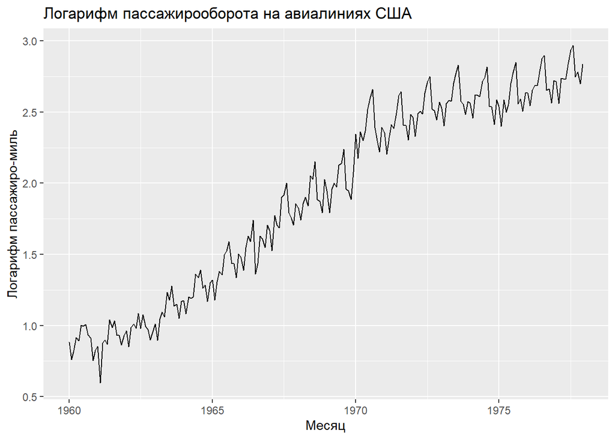

```r
ggplot(passml, aes(date, lnpml)) +
  geom_line() +
  labs(title = "Логарифм пассажирооборота на авиалиниях США") +
  ylab("Логарифм пассажиро-миль") +
  xlab("Месяц")
```

```r
adf.test(passml$lnpml, k = 12, alternative = "stationary")
```

```
##
##  Augmented Dickey-Fuller Test
##
## data:  passml$lnpml
## Dickey-Fuller = -0.66073, Lag order = 12, p-value = 0.9727
## alternative hypothesis: stationary
```

На графике видно, что размах колебаний стал ровнее, чем был, но по критерию Дики-Фуллера ряд все равно не стационарен.

## Сезонное дифференцирование

Обычно чтобы привести ряд к стационарному виду применяют дифференцирование (сезонное, если есть сезонность и простое, чтобы избавиться от тренда). Начнем с сезонного дифференцирования, может быть, простое уже не понадобится.

```r
deseasonal <- diff(passml$lnpml, lag = 12, differences = 1)
```

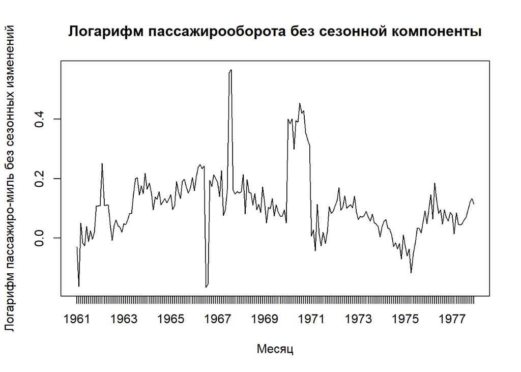

```r
plot(passml$date[c(13:length(passml$lnpml))], deseasonal, type = "l",
     main = "Логарифм пассажирооборота без сезонной компоненты", xlab = "Месяц",
     ylab = "Логарифм пассажиро-миль без сезонных изменений")
```

```r
adf.test(deseasonal, alternative = "stationary")
```

```
##
##  Augmented Dickey-Fuller Test
##
## data:  deseasonal
## Dickey-Fuller = -3.5525, Lag order = 5, p-value = 0.03908
## alternative hypothesis: stationary
```

После сезонного дифференцирования на графике уже не видно “сезонного паттерна”, а p-value критерия Дики-Фуллера значительно уменьшилось. Но попробуем все же еще провести и простое дифференцирование.

## Простое дифференцирование

Чтобы в избавиться от тренда временного ряда проведем дифференцирование с лагом 1.

```r
detrended <- diff(deseasonal, lag = 1, differences = 1)
```

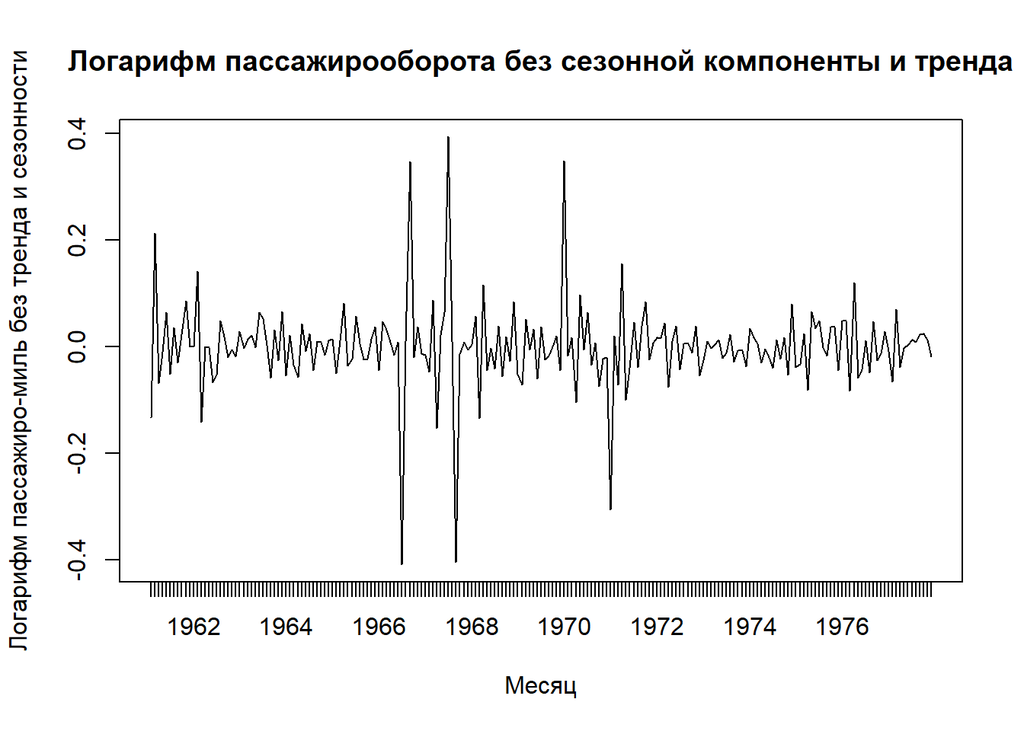

```r
plot(passml$date[c(14:length(passml$lnpml))], detrended, type = "l",
     main = "Логарифм пассажирооборота без сезонной компоненты и тренда",
     xlab = "Месяц",
     ylab = "Логарифм пассажиро-миль без тренда и сезонности")
```

```r
adf.test(detrended, alternative = "stationary")
```

```
##
##  Augmented Dickey-Fuller Test
##
## data:  detrended
## Dickey-Fuller = -6.9202, Lag order = 5, p-value = 0.01
## alternative hypothesis: stationary
```

Отлично! Теперь на графике виден стационарный ряд, что подкрепляется результатом теста Дики-Фуллера. Сделав сезонное и простое дифференцирование мы подобрали уже два параметра для модели *ARIMA(p,**d**,q)(P,**D**,Q)* (выделенные жирным). То есть большое *D* - это порядок сезонного дифференцирования (у нас единица, так как вычитали один раз), а маленькое *d* - это порядок обычного дифференцирования (тоже единица).

# Подбор параметров модели

Для того чтобы подобрать начальное приближение остальных параметров модели, обычно пользуются коррелограммами, показывающими автокорреляцию и частичную автокорреляцию.

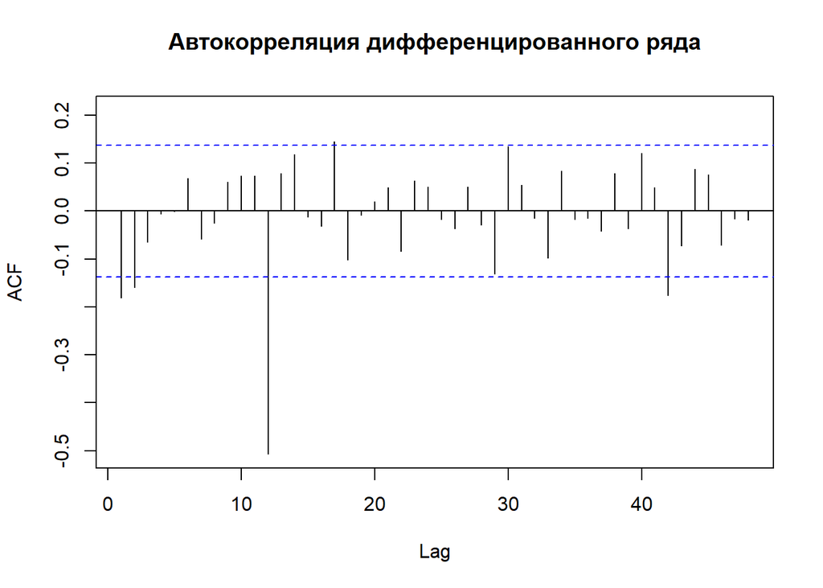

```r
Acf(detrended, lag.max = 48, main='Автокорреляция дифференцированного ряда')
```

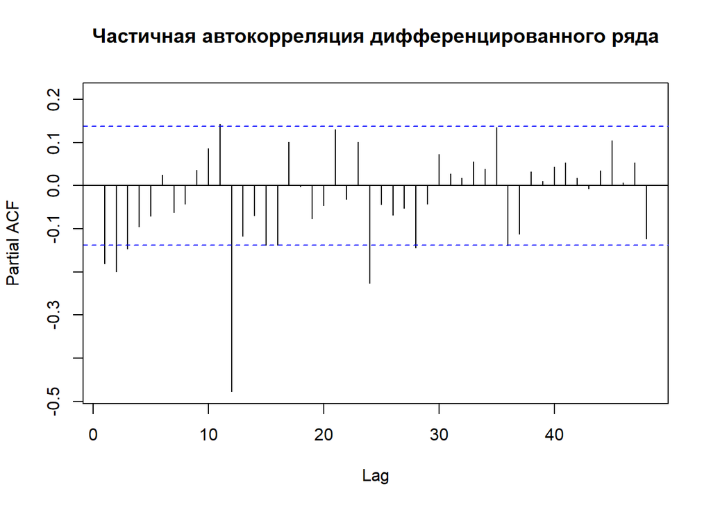

```r
Pacf(detrended, lag.max = 48, main='Частичная автокорреляция дифференцированного ряда')
```

Начальное приближение параметров подбирают следующим образом:

- Q - номер последнего сезонного лага (по порядку) со значимой автокорреляцией −> *Q = 1*
- q - номер последнего несезонного лага со значимой автокорреляцией −> *q = 2*
- P - номер последнего сезонного лага со значимой частичной автокорреляцией −> *P = 2*
- p - номер последнего незезонного лага со значимой частичной автокорреляцией −> *p = 3*

# Выбор модели

Обратите внимание, что на вход модели мы будем подавать исходный временной ряд, только логарифмированный (без дифференцирования), порядок дифференцирования укажем как входной параметр.

```r
lnpml <- passml$lnpml
```

Качество модели оценивается либо информационным критерием Акаике (AIC), либо Байесовским информационным критерием (BIC). Оба эти критерия очень похожи, можно выбирать любой. Чем меньше значение критерия, тем лучше модель.

Обучим модель:

```r
fit1 <- auto.arima(lnpml, d = 1, D = 1, max.p = 3, max.q = 2, max.P = 2,
  max.Q = 1, max.order = 10, seasonal = TRUE, ic = "aic", stepwise = FALSE,
  parallel = FALSE)
fit1
```

```
## Series: lnpml
## ARIMA(2,1,1) with drift
##
## Coefficients:
##          ar1     ar2      ma1   drift
##       0.4431  0.0468  -0.8912  0.0094
## s.e.  0.0763  0.0728   0.0341  0.0016
##
## sigma^2 estimated as 0.01176:  log likelihood=174.22
## AIC=-338.44   AICc=-338.15   BIC=-321.58
```

Как видно из результатов, все что касается сезонной компоненты было опущено. Однако, как мы видели на графике, сезонность точно присутствовала в модели. Попробуем самостоятельно методом перебора подобрать сезонные параметры. Порядок дифференцирования уже подобран - 1, для двух остальных пройдемся циклом от нуля до максимального значения, найденного по кореллограммам.

```r
for (P in c(0, 1, 2)){
  for (Q in c(0, 1)){
    cat("P=",P,"Q=",Q)
    print(arima(lnpml, order = c(2, 1, 1),
      seasonal = list(order = c(P, 1, Q), period = 12)))
  }
}
```

```
## P= 0 Q= 0
## Call:
## arima(x = lnpml, order = c(2, 1, 1), seasonal = list(order = c(P, 1, Q), period = 12))
##
## Coefficients:
##          ar1     ar2      ma1
##       0.6608  0.0228  -0.9532
## s.e.  0.0778  0.0750   0.0347
##
## sigma^2 estimated as 0.005673:  log likelihood = 236.47,  aic = -464.93
## P= 0 Q= 1
## Call:
## arima(x = lnpml, order = c(2, 1, 1), seasonal = list(order = c(P, 1, Q), period = 12))
##
## Coefficients:
##          ar1      ar2      ma1     sma1
##       0.3853  -0.1148  -0.6581  -0.7427
## s.e.  0.1543   0.0893   0.1442   0.0527
##
## sigma^2 estimated as 0.003488:  log likelihood = 281.33,  aic = -552.65
## P= 1 Q= 0
## Call:
## arima(x = lnpml, order = c(2, 1, 1), seasonal = list(order = c(P, 1, Q), period = 12))
##
## Coefficients:
##          ar1      ar2      ma1     sar1
##       0.4744  -0.0572  -0.7684  -0.5231
## s.e.  0.1707   0.1028   0.1606   0.0587
##
## sigma^2 estimated as 0.004138:  log likelihood = 266.83,  aic = -523.67
## P= 1 Q= 1
## Call:
## arima(x = lnpml, order = c(2, 1, 1), seasonal = list(order = c(P, 1, Q), period = 12))
##
## Coefficients:
##          ar1      ar2      ma1     sar1     sma1
##       0.3837  -0.1169  -0.6590  -0.1155  -0.6812
## s.e.  0.1473   0.0875   0.1363   0.0968   0.0798
##
## sigma^2 estimated as 0.003467:  log likelihood = 282.02,  aic = -552.04
## P= 2 Q= 0
## Call:
## arima(x = lnpml, order = c(2, 1, 1), seasonal = list(order = c(P, 1, Q), period = 12))
##
## Coefficients:
##          ar1      ar2      ma1     sar1     sar2
##       0.4157  -0.1124  -0.7044  -0.6857  -0.2966
## s.e.  0.1393   0.0886   0.1271   0.0671   0.0669
##
## sigma^2 estimated as 0.003739:  log likelihood = 275.98,  aic = -539.95
## P= 2 Q= 1
## Call:
## arima(x = lnpml, order = c(2, 1, 1), seasonal = list(order = c(P, 1, Q), period = 12))
##
## Coefficients:
##          ar1      ar2      ma1     sar1    sar2     sma1
##       0.3832  -0.1165  -0.6590  -0.1045  0.0126  -0.6919
## s.e.  0.1476   0.0879   0.1369   0.1366  0.1112   0.1218
##
## sigma^2 estimated as 0.003467:  log likelihood = 282.02,  aic = -550.05
```

Ориентируясь на критерий информативности Акаике (он минимизируется), найлучшей моделью оказывается следующая: ARIMA(2,1,1)(0,1,1). Сохраним эту модель.

```r
fit2 <- arima(lnpml, order = c(2, 1, 1),
      seasonal = list(order = c(0, 1, 1), period = 12))
fit2
```

```
##
## Call:
## arima(x = lnpml, order = c(2, 1, 1), seasonal = list(order = c(0, 1, 1), period = 12))
##
## Coefficients:
##          ar1      ar2      ma1     sma1
##       0.3853  -0.1148  -0.6581  -0.7427
## s.e.  0.1543   0.0893   0.1442   0.0527
##
## sigma^2 estimated as 0.003488:  log likelihood = 281.33,  aic = -552.65
```

# Анализ остатков модели

Чтобы понять, действительно ли хороша модель, посмотрим на ее остатки.

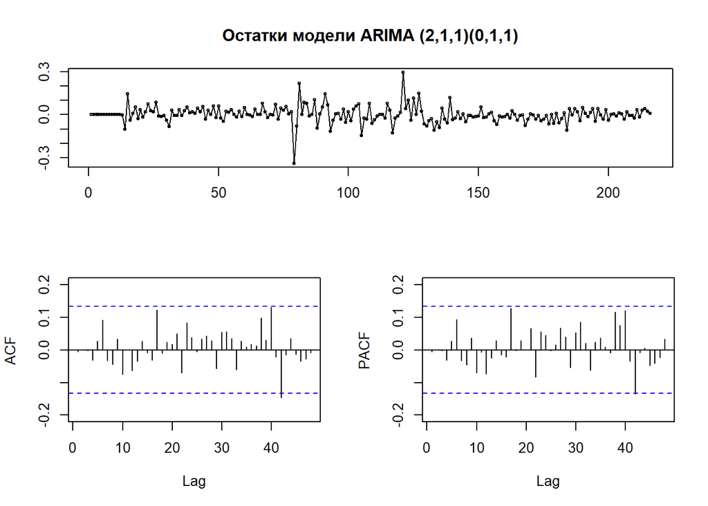

```r
tsdisplay(residuals(fit2), lag.max = 48, main = "Остатки модели ARIMA (2,1,1)(0,1,1)")
```

Какими должны быть хорошие остатки модели? Они должны быть независимыми (смотрим, чтобы лаги на коррелограммах не выходили за пределы доверительных интервалов для нулевых значений, т.е. были незначимыми) и в среднем равны нулю (что наблюдается на первом графике).

Также посмотрим и на остатки первой модели, где не учитывался сезонный фактор:

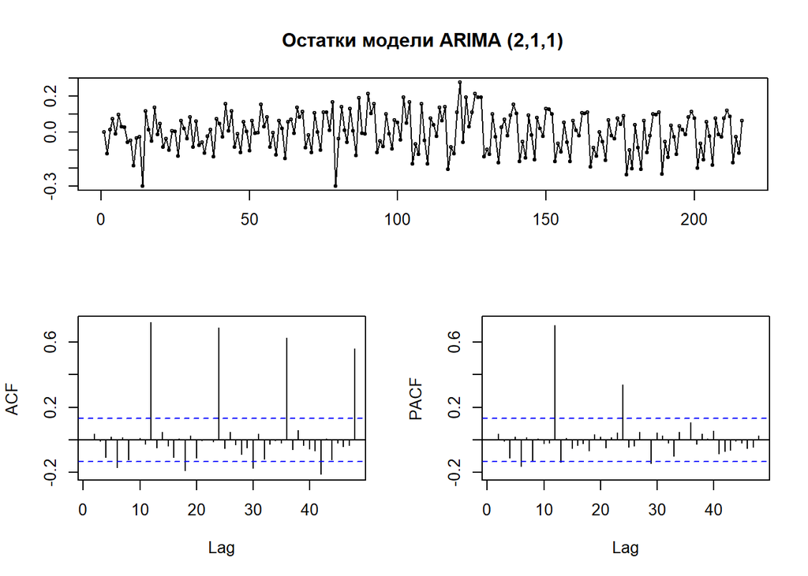

```r
tsdisplay(residuals(fit1), lag.max = 48, main = "Остатки модели ARIMA (2,1,1)")
```

В данном случае на коррелограммах явно видно, что остатки не независимы.

# Прогноз

Посмотрим на двухлетний прогноз прологарифмированного ряда (параметр `h` функции `forecast` отвечает за число периодов, на которые надо прогнозировать).

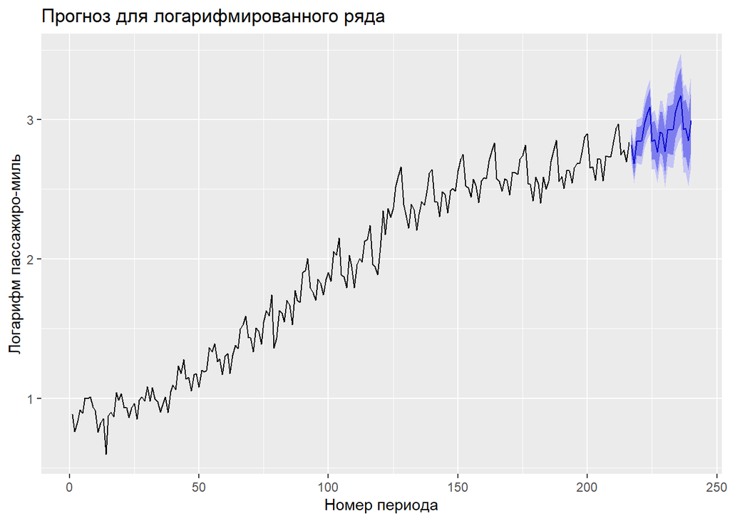

```r
lnfcst <- forecast(fit2, h =24)
autoplot(lnfcst, main = "Прогноз для логарифмированного ряда") +
         labs(x = "Номер периода",
         y = "Логарифм пассажиро-миль",
         fill = "Доверительный интервал")
```

Выглядит нормально. Теперь надо привести прогноз в нужный вид, то есть провести операцию, обратную натуральному логарифмированию - это возведение числа *е* в степень:

$$y_f = e^{y_f'}$$

```r
fcst <- exp(lnfcst$mean)
```

Построим на графике исходный ряд и прогноз.

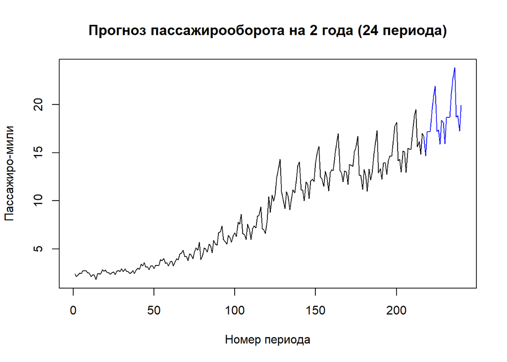

```r
plot(c(passml$Passenger_miles,fcst), type = "l",
     main = "Прогноз пассажирооборота на 2 года (24 периода)",
     xlab = "Номер периода", ylab = "Пассажиро-мили")
lines(fcst, col = "blue")
```

Похоже, что прогнозные значения довольно неплохо повторяют тенденции исходного временного ряда.